# Homework 2

#### Question 5

ANSWER: The **t-test** is used to compare *means*, whereas the **wilcoxon’s** test the *ordering* of the data. The **t-test** is a *parametric* test whereas the **wilcoxon’s** is a *non-parametric* test, meaning the **t-test** follows *more assumptions* than the wilcoxon’s (i.e. t-test assumptions assumes normal distribution and equal variance). Because the **t-test** is the parametric version and follows strict assumptions it is more conservative and a stronger test to perform for significance when comparing two groups. With my gaussian distribution, simulations we can see that the t-test (black line) has a higher power than the wilcoxon test (red line), although the lines were very close. However, with my non-gaussian distribution (poisson), there is a larger difference between t-test and wilcoxon with the t-test having higher power than wilcoxon.

```r
# gaussian distribution
n <- 10
nsim <- 1000
d <- seq(0,2, len = 10)

pt <- pw <- matrix(NA, 10, nsim)
for(j in 1:10) {
  for(i in 1:nsim) {
    y <- rnorm(n, mean = d[j], sd = 1)
    pt[j,i] <- t.test(y)$p.value
    pw[j,i] <- wilcox.test(y)$p.value
  }
}

powert <- apply(pt<.05,1,mean)
powerw <- apply(pw<.05,1,mean)

print(rbind(powert, powerw))
```

```
##         [,1]  [,2]  [,3]  [,4]  [,5]  [,6]  [,7]  [,8]  [,9] [,10]
## powert 0.057 0.109 0.244 0.496 0.732 0.861 0.968 0.994 0.999     1
## powerw 0.057 0.099 0.231 0.484 0.717 0.854 0.958 0.993 0.996     1
```

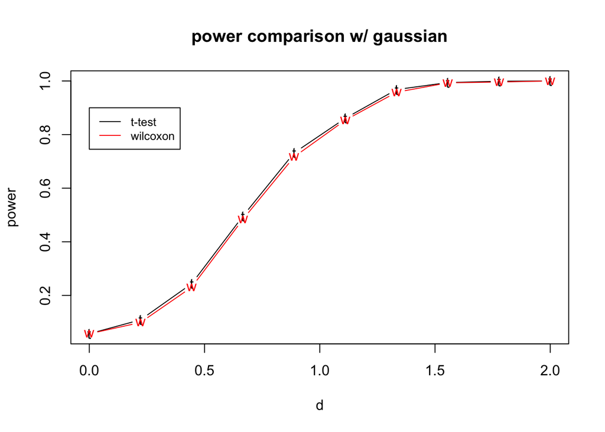

```r
plot(d, powert, type = "b", pch = "t", xlab = "d", ylab = "power", main = "power comparison w/ gaussian")
points(d, powerw, type = "b", pch = "w", col = "red")
legend(0, .9, legend = c("t-test", "wilcoxon"),
       col = c("black", "red"), lty = 1:1, cex = .8)
```

```r
n <- 10
nsim <- 500
d <- seq(0,2, len = 10)

pt <- pw <- matrix(NA, 10, nsim)
for(j in 1:10) {
  for(i in 1:nsim) {
    y <- rpois(n, lambda = d[j])
    pt[j,i] <- t.test(y)$p.value
    pw[j,i] <- wilcox.test(y)$p.value
  }
}
```

[output not shown]

[output cut: 944 more lines]

[output not shown]

```r
?rpois
powert <- apply(pt<.05,1,mean)
powerw <- apply(pw<.05,1,mean)

print(rbind(powert, powerw))
```

```
##        [,1] [,2] [,3] [,4]  [,5]  [,6]  [,7]  [,8]  [,9] [,10]
## powert   NA   NA   NA   NA 0.872 0.916 0.974 0.992 0.994 0.998
## powerw   NA   NA   NA   NA 0.706 0.842 0.902 0.972 0.982 0.994
```

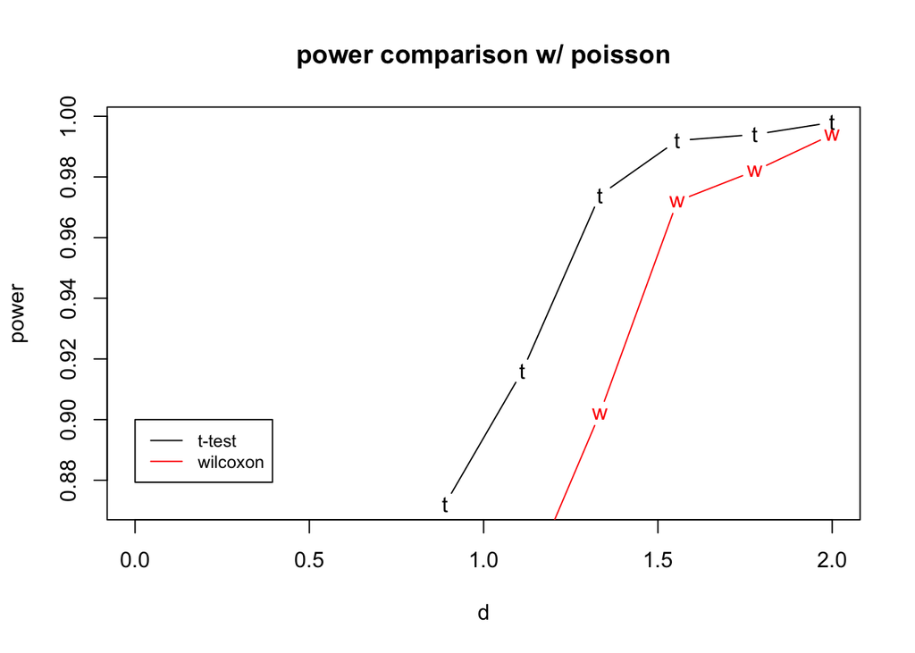

```r
plot(d, powert, type = "b", pch = "t", xlab = "d", ylab = "power", main = "power comparison w/ poisson")
points(d, powerw, type = "b", pch = "w", col = "red")
legend(0, .9, legend = c("t-test", "wilcoxon"),
       col = c("black", "red"), lty = 1:1, cex = .8)
```

#### Question 6

ANSWER: To compare two proportions of recieving dealth penalty from two independent groups (white and black), we will conduct a 2-sample test for equality of proportions with continuity correction.

- H0 (null hypothesis): The proportion of white population is equal to proportion of black population that would receive the death penalty (p_white = p_black).
- HA (alternative hypothesis): The proportion of white population is not equal to proportion of black population that would receive the death penalty.

In conclusion, with a *p-value = 0.7689* (p > 0.05), we fail to reject our null hypothesis meaning the proportion of white pop. *is equal* to the proportion of black pop. that receives the death penalty with a *95 CI of -0.05791211 - 0.09059283*. The *estimates of proportion for white and black populations is 0.1187500 and 0.1024096*, respectively. The Pearson’s chi-squared test statistic is *X-squared = 0.086343*.

```r
## upload data

# 19/160 white defendents death penalty
# 17/166 black defendants death penalty

# compare two proportions

x = c(19,17) # x = vector of counts as success
n = c(160, 166) # n = vector of count trials
alternative = "two.sided"
# alternative = character string specifying the alternative hypothesis, could also put one.sided
conf.level = 0.95 # confidence level

## R function for Z test
prop.test(x = x,  # success
          n = n,  # number of trials
          alternative = alternative,
          conf.level = conf.level)
```

```
##
##  2-sample test for equality of proportions with continuity correction
##
## data:  x out of n
## X-squared = 0.086343, df = 1, p-value = 0.7689
## alternative hypothesis: two.sided
## 95 percent confidence interval:
##  -0.05791211  0.09059283
## sample estimates:
##    prop 1    prop 2
## 0.1187500 0.1024096
```

```r
# X-squared = 0.086343 which is the Pearson's chi-squared test statisitic
# p-value = 0.7689
# prop 1 (white) estimate = 0.1187500
# prop 2 (black) estimate = 0.1024096
```

#### Question 7

ANSWER: To test of goodness of fit establishes whether or not an observed frequency distribution differs from a theoretical distribution. I have written a chi-square test for given probabilities for two scenarios: tomatoes and birth hour.

For **tomatoes**,

- H0 (null hypothesis): The observed frequency of tomato phenologies is the same as a theoretical distribution
- HA (alternative hypothesis): The observed frequency of tomato phenologies is not the same as a theoretical distribution

In conclusion, my **p-value = 0.6895** (p > 0.05), so we fail to reject the null hypothesis which means tomoato phenologies are the same as the theoretical distribution. AKA, the **tomato data is consistent with Mendel’s law**.

For **birth hour**,

- H0 (null hypothesis): The observed frequency of birth hour is the same as a theoretical distribution
- HA (alternative hypothesis): The observed frequency of birth hour is not the same as a theoretical distribution

In conclusion, my **p-value = < 2.2e-16** (p < 0.05), so we reject the null hypothesis which means birth hours are not the same as the theoretical distribution. AKA, the **birth hour data is not consistent throughout the night** and is more likely to commence very late at night.

```r
# write a function for goodness of fit tests with category probabilities


## for tomato example

x = c(926, 288, 293, 104) # vector of tomato phenotypes
chisq.test(x = x,
           p = c(9,3,3,1)/16)
```

```
##
##  Chi-squared test for given probabilities
##
## data:  x
## X-squared = 1.4687, df = 3, p-value = 0.6895
```

```r
# p-value = 0.6895
# X-squared = 1.4687

## for birth hour example
length(x)
```

```
## [1] 4
```

```r
x = c(52,73,89,88,68,47,58,47,48,53,47,34,21,31,40,24,37,31,47,34,36,44,78,59) # vector of birth hours
chisq.test(x = x,
           p = rep(1,24)/24)
```

```
##
##  Chi-squared test for given probabilities
##
## data:  x
## X-squared = 162.78, df = 23, p-value < 2.2e-16
```

```r
# p-value = < 2.2e-16
# X-squared = 162.78
```

#### Question 8

ANSWER: I will use a *contingency table* to answer questions regarding the independence of both political views and marijuana usage. To test for independency I will test that an individual’s category with respect to variable (political party) is independent of the category with respect to variable (marijuana usage).

- H0 (null hypothesis): In terms of the number of times individuals used marijuana, the effect of usage level is independent of the effect of political views. (p_ij = p_i + p + j, where j = usage level and i = political party).
- HA (alternative hypothesis): In terms of the number of times individuals used marijuana, the effect of usage level is not independent of the effect of political views.

In conclusion, our p-value from a pearson’s chi-square test is *p = 3.043e-13* (p < 0.05), meaning we reject our null hypothesis and can say signficantly that political party and marijuana usage level *are not two independent variables*.

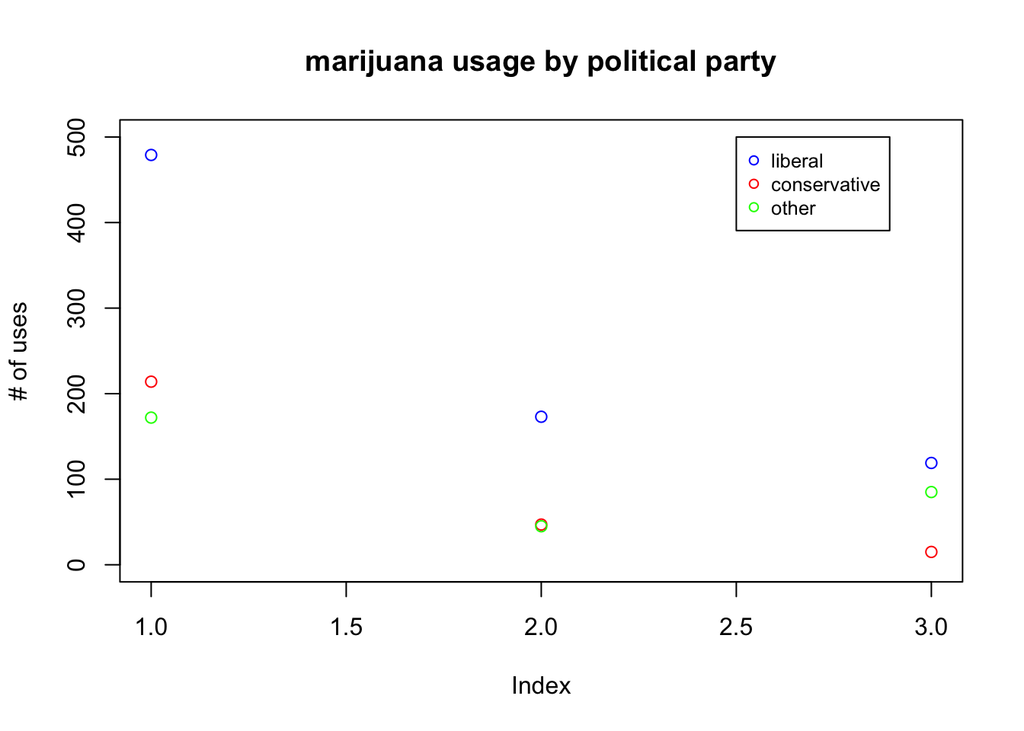

```r
## upload data

ma <- matrix(c(479, 173, 119, 214,47,15,172,45,85),3,3 )


## visualize data

liberal <- c(479, 173, 119)
conservative <- c(214,47,15)
other <- c(172,45,85)

group <- c(liberal, conservative, other)

names(group) <- c("liberal", "conservative", "other")


plot(liberal, ylim = c(0, 500), main = "marijuana usage by political party", ylab = "# of uses", col = "blue")
points(conservative, col = "red")
points(other, col = "green")
legend(2.5,500, legend = c("liberal", "conservative", "other"),
       col = c("blue", "red", "green"), pch = 1, cex = .8)
```

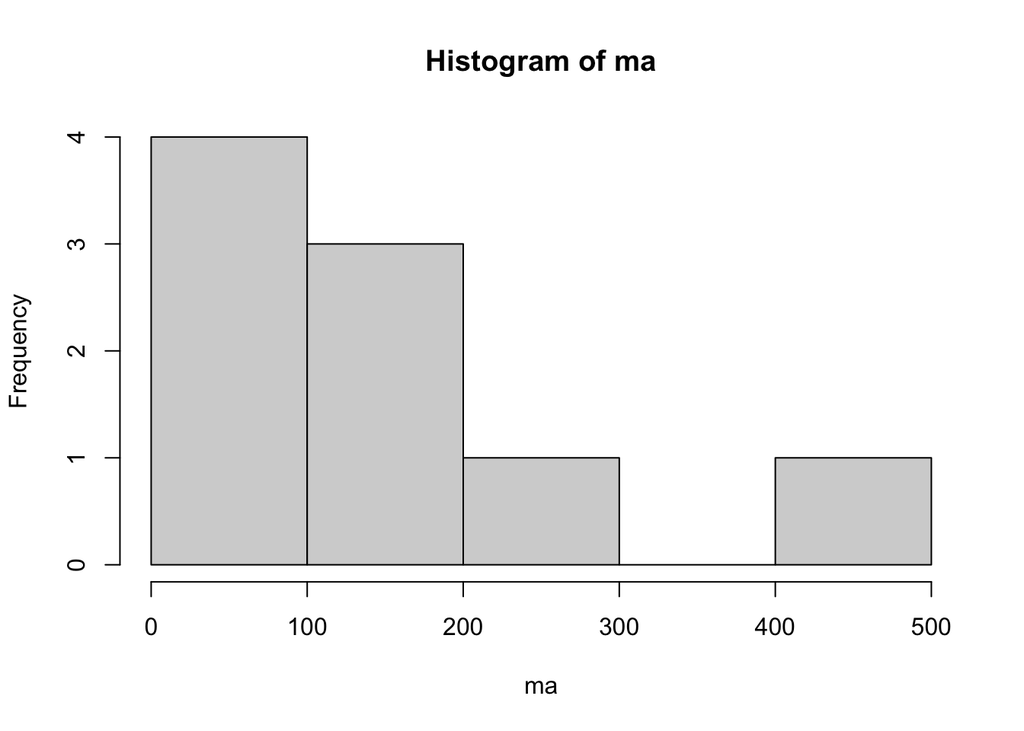

```r
# check distribution
hist(ma)
```

```r
## chi square test

chisq.test(ma)
```

```
##
##  Pearson's Chi-squared test
##
## data:  ma
## X-squared = 64.654, df = 4, p-value = 3.043e-13
```

```r
# p-value = 3.043e-13
# X-squared = 64.654


# p < 0.05, can reject null hypothesis
```

#### Question 9

- H0 (null hypothesis): the true probability of success (selecting defective battery) is equal to .75
- HA (alternative hypothesis): the true probability of success (selecting defective battery) is not equal to .75

```r
## upload data

freq <- c(26,51,47,16,10)


success <- 51+47+16+10 # defined for number of defective 1,2,3,4
failure <- 26 # defined for number of defective = 0
total <- success + failure # 150 total

# conduct binomial test with probability of success equal to 3/4
binom.test(c(success, total), p = 3/4)
```

```
##
##  Exact binomial test
##
## data:  c(success, total)
## number of successes = 124, number of trials = 274, p-value < 2.2e-16
## alternative hypothesis: true probability of success is not equal to 0.75
## 95 percent confidence interval:
##  0.3925903 0.5135564
## sample estimates:
## probability of success
##              0.4525547
```

#### Question 10

ANSWER: The populations (present/absent) and each population is divided into the same categories of insulin dose (<.25, .25-.49, .50-.74, .75-99, >=1). I will run a two-way tables to calculate the pearson’s chi-squared test.

- H0 (null hypothesis): the proportion of individuals who belong to different categories of insulin dose is the same as individuals part of present and absent variables.
- HA (alternative hypothesis): the proportion of individuals who belong to different categories of insulin dose is not the same as individuals part of present and absent variables.

In conclusion, with a **p-value = 0.01182** (p < 0.05) we reject the null hypothesis and state that the presence/absence of **hypoglycemia is not independent of insulin dosage**.

```r
## upload data

x <- matrix(c(4,40,21,74,29,59,15,26,12,46),2,5)

# run chi square test
chisq.test(x)
```

```
##
##  Pearson's Chi-squared test
##
## data:  x
## X-squared = 12.892, df = 4, p-value = 0.01182
```

```r
# p-value = 0.01182
# X-squared = 12.892
```